# Unit 11 From Records to Insights - Analyse von Patientenakten mit Clinical AI

# From Cohort to Question – Eine klinische Fragestellung entwickeln

Ziel des Kapitels: Sie sollen wirklich einmal die CSV-Dateien gesehen haben, die Teil einer klinischen Datenbank sind.

Vorbereitung des R Notebooks Clear workspace: Löschen Sie die alte Umgebung und starten Sie mit einer neuen Analyse

```r
rm(list=ls())
```

## Import der Daten

Um mit klinischen Daten zu arbeiten, nutzen wir den frei verfügbaren Demo-Datensatz der MIMIC-IV-Datenbank (einzelne z.B. über Patient ID relational verknüpfte CSV-Dateien) sowie einen bereits vorverarbeiteten Datensatz zu einer klinischen Fragestellung, bei dem die Filter- und Bereinigungsschritte bereits erfolgt sind. Der Vorteil des Demo-Datensatzes ist, dass Sie relativ leicht damit arbeiten können, der klare Nachteil, dass nur 100 Patienten enthalten sind. Der Full Cohort Datensatz stammt aus MIMIC-II.

Zu Ihrer Bequemlichkeit können Sie die CSVs der MIMICIV Datenbank zusammen mit dem bereits vorverarbeiteten Full Cohort Datensatz aus einem zu diesem Zweck angelegten R-Workspace importieren:

```r
load("MIMICIV_Demo_and_MIMICII_Full_Cohort.RData")
```

## Exploration der Daten

Sehen Sie sich den Inhalt der einzelnen CSV Dateien an, entweder indem Sie die Daten in R laden und z.B. mit head() oder View() durchsehen indem Sie auf die Webseite https://physionet.org/content/mimic-iv-demo/2.2/ gehen und die Ordner hosp und icu auswählen, um die CSVs durch Klick darauf betrachten oder indem Sie die CSV Files als ZUP-Datei herunterladen, um Sie in jeder beliebigen Datenanalyse-Software zu laden: https://physionet.org/content/mimic-iv-demo/get-zip/2.2/

Den Full Cohort Datensatz können Sie auch händisch herunterladen: https://www.physionet.org/files/mimic2-iaccd/1.0/full_cohort_data.csv

Setzen Sie parallel zur Analyse mit Ihrer Statistiksoftware auch ein Sprachmodell ein. Hier können Sie die Demo-Einzel-CSVs als auch den Full Cohort Datensatz direkt z.B. in Chat GPT laden (und dann auch bequem anzeigen und in Excel kopieren) und promptbasiert analysieren und visualisieren, oder aber Code für Ihre Analyse in R erzeugen. Mit den MIMIC_IV_Full Daten dürfen Sie dies nicht tun, wie die zu diesem Zweck zu schließende Nutzungsbereinbarung explizit vorschreibt. Für die Arbeit mit Demo-Daten ist dies nicht von Belang.

Nun haben Sie auf die eine oder andere Weise klinische Daten geladen und sind einsatzbereit. Sehen Sie sich nun also in R die Variablen des Global Environments oder in anderer Software die einzelnen Tabellen an. patients → Wer ist die Person? admissions → Welche Krankenhausaufenthalte gibt es? icustays → Welche ICU-Aufenthalte gibt es? diagnoses_icd → Welche Diagnosen wurden kodiert? d_icd_diagnoses → Was bedeuten diese Codes?

## Demo-Kohorte aus MIMIC-IV-Tabellen erstellen

Erstellen Sie eine Tabelle, in der jeder ICU-Aufenthalt eine Zeile darstellt und mindestens Geschlecht, Alter, ICU Length of Stay und Hauptdiagnose enthält. Nutzen Sie ein Sprachmodell, um den entsprechenden Befehl mit JOINS zu verfassen, dass Sie mit dplyr eine Tabelle als Output bekommen.

Zu diesem Zweck müssen die geladenen Tabellen aus MIMIC-IV Demo nun so miteinander verbunden werden, dass nur ICU Length of Stay als Zielvariable gesehen wird, und verschiedene Abhängigkeiten untersucht werden können, darunter: - Geschlecht - Alter - Hauptdiagnose (Gruppenname im Sinne von ICD-10)

Erstellen Sie eine Tabelle, aus der die Häufigkeit der Hauptdiagnosen hervorgeht, sodass Sie untersuchen können, wie sie sich auf verschiedene Einflussfaktoren, darunter Geschlecht, verteilen. Haben (bezogen auf die Grundgesamtheit von 100 Patienten) männliche Patienten andere Hauptdiagnosen als weibliche Patientinnen? Finden Sie eine geeignete Visualisierung. Nutzen Sie ein Sprachmodell, um den entsprechenden Befehl mit JOINS zu verfassen, dass Sie mit dplyr eine Tabelle als Output bekommen, die Sie später weiter analysieren können

Mögliche Lösung: Prompt und RData Datei als Input: Kannst du auf dieser Basis diese Aufgabe lösen, sodass ich dplyr code bekomme: Zu diesem Zweck müssen die geladenen Tabellen aus MIMIC-IV Demo nun so miteinander verbunden werden, dass nur ICU Length of Stay als Zielvariable gesehen wird, und verschiedene Abhängigkeiten untersucht werden können, darunter: - Geschlecht - Alter - Hauptdiagnose (Gruppenname im Sinne von ICD-10)

```r
library(dplyr)
library(lubridate)

# ------------------------------------------------------------
# 1. Hauptdiagnose pro Krankenhausaufenthalt bestimmen
# ------------------------------------------------------------

main_diagnosis <- diagnoses_icd %>%

  # Für diese Übung nur ICD-10-Diagnosen
  filter(icd_version == 10,
         seq_num == 1) %>%

  # Diagnosebezeichnung ergänzen
  left_join(
    d_icd_diagnoses,
    by = c("icd_code", "icd_version")
  ) %>%

  # ICD-10-Kapitel aus dem ersten Buchstaben ableiten
  mutate(
    icd10_group = case_when(
      substr(icd_code, 1, 1) %in% c("A", "B") ~
        "Certain infectious and parasitic diseases",

      substr(icd_code, 1, 1) == "C" ~
        "Neoplasms",

      substr(icd_code, 1, 1) == "D" ~
        "Diseases of blood / immune disorders",

      substr(icd_code, 1, 1) == "E" ~
        "Endocrine, nutritional and metabolic diseases",

      substr(icd_code, 1, 1) == "F" ~
        "Mental and behavioural disorders",

      substr(icd_code, 1, 1) == "G" ~
        "Diseases of the nervous system",

      substr(icd_code, 1, 1) == "H" ~
        "Diseases of the eye or ear",

      substr(icd_code, 1, 1) == "I" ~
        "Diseases of the circulatory system",

      substr(icd_code, 1, 1) == "J" ~
        "Diseases of the respiratory system",

      substr(icd_code, 1, 1) == "K" ~
        "Diseases of the digestive system",

      substr(icd_code, 1, 1) == "L" ~
        "Diseases of the skin and subcutaneous tissue",

      substr(icd_code, 1, 1) == "M" ~
        "Diseases of the musculoskeletal system",

      substr(icd_code, 1, 1) == "N" ~
        "Diseases of the genitourinary system",

      substr(icd_code, 1, 1) %in% c("O", "P", "Q") ~
        "Pregnancy, perinatal and congenital conditions",

      substr(icd_code, 1, 1) == "R" ~
        "Symptoms, signs and abnormal findings",

      substr(icd_code, 1, 1) %in% c("S", "T") ~
        "Injury, poisoning and external causes",

      substr(icd_code, 1, 1) == "Z" ~
        "Factors influencing health status",

      TRUE ~ "Other"
    )
  ) %>%

  select(
    subject_id,
    hadm_id,
    icd_code,
    long_title,
    icd10_group
  )


# ------------------------------------------------------------
# 2. ICU-Kohorte erstellen
#    Eine Zeile = ein ICU-Aufenthalt
# ------------------------------------------------------------

mimic_demo_cohort <- icustays %>%

  # Patienteninformationen hinzufügen
  left_join(
    patients %>%
      select(
        subject_id,
        gender,
        anchor_age,
        anchor_year
      ),
    by = "subject_id"
  ) %>%

  # Aufnahmeinformationen ergänzen
  left_join(
    admissions %>%
      select(
        subject_id,
        hadm_id,
        admittime
      ),
    by = c("subject_id", "hadm_id")
  ) %>%

  # Alter zum Zeitpunkt der Krankenhausaufnahme berechnen
  mutate(
    age = anchor_age + year(admittime) - anchor_year
  ) %>%

  # Hauptdiagnose ergänzen
  left_join(
    main_diagnosis,
    by = c("subject_id", "hadm_id")
  ) %>%

  # Nur die für die Analyse benötigten Variablen behalten
  select(
    subject_id,
    hadm_id,
    stay_id,
    gender,
    age,
    los,
    icd_code,
    long_title,
    icd10_group
  ) %>%

  # Outcome verständlicher benennen
  rename(
    icu_los = los,
    main_diagnosis = long_title
  )
```

## Mit der fertigen Full cohort Tabelle verschiedene Variablen hinsichtlich des Geschlechts untersuchen

### Variablen als Faktoren speichern

```r
dat <- full_cohort
bincols <- colMeans((dat == 1 | dat == 0), na.rm = TRUE) == 1

for(i in seq_along(bincols)) {
  if(bincols[i]) {
    dat[[i]] <- as.factor(dat[[i]])
  }
}
```

### Variablen im Datensatz

Welche Variablen sind enthalten? Verstehen Sie die Variablen?

```r
names(dat)
```

```
 [1] "aline_flg"          "icu_los_day"        "hospital_los_day"   "age"                "gender_num"         "weight_first"       "bmi"                "sapsi_first"
 [9] "sofa_first"         "service_unit"       "service_num"        "day_icu_intime"     "day_icu_intime_num" "hour_icu_intime"    "hosp_exp_flg"       "icu_exp_flg"
[17] "day_28_flg"         "mort_day_censored"  "censor_flg"         "sepsis_flg"         "chf_flg"            "afib_flg"           "renal_flg"          "liver_flg"
[25] "copd_flg"           "cad_flg"            "stroke_flg"         "mal_flg"            "resp_flg"           "map_1st"            "hr_1st"             "temp_1st"
[33] "spo2_1st"           "abg_count"          "wbc_first"          "hgb_first"          "platelet_first"     "sodium_first"       "potassium_first"    "tco2_first"
[41] "chloride_first"     "bun_first"          "creatinine_first"   "po2_first"          "pco2_first"         "iv_day_1"
```

### Struktur des Datensatzes

```r
str(dat)
```

```
'data.frame':   1776 obs. of  46 variables:
 $ aline_flg         : Factor w/ 2 levels "0","1": 2 1 1 2 2 1 2 2 2 2 ...
 $ icu_los_day       : num  7.63 1.14 2.86 0.58 1.75 1.38 7.06 15.3 3.79 7.14 ...
 $ hospital_los_day  : int  13 1 5 3 5 9 27 33 4 7 ...
 $ age               : num  72.4 64.9 36.5 44.5 23.7 ...
 $ gender_num        : Factor w/ 2 levels "0","1": 2 1 1 1 2 2 2 1 1 1 ...
 $ weight_first      : num  75 55 70 NA 95.2 72 90 69.7 52.6 61.5 ...
 $ bmi               : num  29.9 20.1 27.1 NA 28.5 ...
 $ sapsi_first       : int  15 NA 16 21 18 14 15 16 9 13 ...
 $ sofa_first        : int  9 5 5 7 7 5 6 8 5 9 ...
 $ service_unit      : chr  "SICU" "MICU" "MICU" "SICU" ...
 $ service_num       : Factor w/ 2 levels "0","1": 2 1 1 2 2 2 2 1 1 1 ...
 $ day_icu_intime    : chr  "Friday   " "Saturday " "Friday   " "Saturday " ...
 $ day_icu_intime_num: int  6 7 6 7 7 1 7 5 6 6 ...
 $ hour_icu_intime   : int  6 17 3 4 7 12 22 14 21 10 ...
```

[output cut: 32 more lines]

### Summary

```r
summary(dat)
```

```
 aline_flg  icu_los_day     hospital_los_day       age        gender_num  weight_first         bmi         sapsi_first      sofa_first        service_unit  service_num   day_icu_intime
 0:792     Min.   : 0.500   Min.   :  1.000   Min.   :15.18   0  : 750   Min.   : 30.00   Min.   :12.78   Min.   : 3.00   Min.   : 0.000   Length   :1776   0:794       Length   :1776
 1:984     1st Qu.: 1.370   1st Qu.:  3.000   1st Qu.:38.25   1  :1025   1st Qu.: 65.40   1st Qu.:22.62   1st Qu.:11.00   1st Qu.: 4.000   N.unique :   3   1:982       N.unique :   7
           Median : 2.185   Median :  6.000   Median :53.68   NAs:   1   Median : 77.00   Median :26.32   Median :14.00   Median : 6.000   N.blank  :   0               N.blank  :   0
           Mean   : 3.346   Mean   :  8.111   Mean   :54.38              Mean   : 80.08   Mean   :27.83   Mean   :14.14   Mean   : 5.821   Min.nchar:   4               Min.nchar:   9
           3rd Qu.: 4.003   3rd Qu.: 10.000   3rd Qu.:72.76              3rd Qu.: 90.00   3rd Qu.:30.80   3rd Qu.:17.00   3rd Qu.: 7.000   Max.nchar:   4               Max.nchar:   9
           Max.   :28.240   Max.   :112.000   Max.   :99.11              Max.   :257.60   Max.   :98.80   Max.   :32.00   Max.   :17.000
                                                                         NAs    :110      NAs    :466     NAs    :85      NAs    :6
 day_icu_intime_num hour_icu_intime hosp_exp_flg icu_exp_flg day_28_flg mort_day_censored censor_flg sepsis_flg chf_flg  afib_flg renal_flg liver_flg copd_flg cad_flg  stroke_flg mal_flg
 Min.   :1.000      Min.   : 0.00   0:1532       0:1606      0:1493     Min.   :   0.0    0: 497     0:1776     0:1563   0:1569   0:1716    0:1677    0:1619   0:1653   0:1554     0:1520
 1st Qu.:2.000      1st Qu.: 3.00   1: 244       1: 170      1: 283     1st Qu.: 434.3    1:1279                1: 213   1: 207   1:  60    1:  99    1: 157   1: 123   1: 222     1: 256
 Median :4.000      Median : 9.00                                       Median : 731.0
 Mean   :4.054      Mean   :10.59                                       Mean   : 614.3
 3rd Qu.:6.000      3rd Qu.:19.00                                       3rd Qu.: 731.0
 Max.   :7.000      Max.   :23.00                                       Max.   :3094.1

 resp_flg    map_1st           hr_1st          temp_1st         spo2_1st        abg_count         wbc_first        hgb_first     platelet_first   sodium_first   potassium_first
 0:1211   Min.   :  5.00   Min.   : 30.00   Min.   : 32.00   Min.   :  4.00   Min.   :  0.000   Min.   :  0.17   Min.   : 2.00   Min.   :  7.0   Min.   :105.0   Min.   :1.900
 1: 565   1st Qu.: 76.67   1st Qu.: 74.75   1st Qu.: 96.90   1st Qu.: 98.00   1st Qu.:  1.000   1st Qu.:  8.20   1st Qu.:11.10   1st Qu.:182.0   1st Qu.:137.0   1st Qu.:3.600
          Median : 87.00   Median : 87.00   Median : 98.10   Median :100.00   Median :  3.000   Median : 11.30   Median :12.70   Median :239.0   Median :140.0   Median :4.000
          Mean   : 88.25   Mean   : 87.91   Mean   : 97.79   Mean   : 98.43   Mean   :  5.985   Mean   : 12.32   Mean   :12.55   Mean   :246.1   Mean   :139.6   Mean   :4.108
          3rd Qu.: 99.00   3rd Qu.:100.00   3rd Qu.: 99.30   3rd Qu.:100.00   3rd Qu.:  7.000   3rd Qu.: 15.00   3rd Qu.:14.12   3rd Qu.:297.0   3rd Qu.:142.0   3rd Qu.:4.400
          Max.   :195.00   Max.   :158.00   Max.   :104.80   Max.   :100.00   Max.   :115.000   Max.   :109.80   Max.   :19.00   Max.   :988.0   Max.   :165.0   Max.   :9.800
                                            NAs    :3                                           NAs    :8        NAs    :8       NAs    :8       NAs    :5       NAs    :5
   tco2_first    chloride_first    bun_first      creatinine_first   po2_first       pco2_first        iv_day_1
 Min.   : 2.00   Min.   : 78.0   Min.   :  2.00   Min.   : 0.000   Min.   : 22.0   Min.   :  8.00   Min.   :    0.0
 1st Qu.:22.00   1st Qu.:101.0   1st Qu.: 11.00   1st Qu.: 0.700   1st Qu.:108.0   1st Qu.: 36.00   1st Qu.:  329.8
 Median :24.00   Median :104.0   Median : 15.00   Median : 0.900   Median :195.0   Median : 41.00   Median : 1081.5
 Mean   :24.42   Mean   :103.8   Mean   : 19.28   Mean   : 1.096   Mean   :227.6   Mean   : 43.41   Mean   : 1622.9
 3rd Qu.:27.00   3rd Qu.:107.0   3rd Qu.: 22.00   3rd Qu.: 1.100   3rd Qu.:323.0   3rd Qu.: 47.00   3rd Qu.: 2493.9
 Max.   :62.00   Max.   :133.0   Max.   :139.00   Max.   :18.300   Max.   :634.0   Max.   :158.00   Max.   :13910.0
 NAs    :5       NAs    :5       NAs    :5        NAs    :6        NAs    :186     NAs    :186      NAs    :143
```

Wie kommt die Full_Cohort Tabelle zustande? Welche Informationen aus welchen Tabellen müssen wie verknüpft worden sein? Nutzen Sie auch Chat GPT, um diese Fragen anhand der eingegebenen CSV-Files zu beantworten und prüfen Sie kritisch, ob der LLM-Output technisch und medizinisch Sinn ergibt

# Explore Before You Explain – Kohorte und Zusammenhänge explorieren

## Häufigste Hauptdiagnosen

Häufigste Hauptdiagnosen, analysiert nach Geschlecht darstellen (mit Histogramm oder Barplot) aus MIMIC-IV-Demo-Tabelle

Mögliche Lösung:

```r
mimic_demo_cohort %>%
  count(icd10_group, sort = TRUE)
```

| icd10_group | n |
| --- | --- |
| NA | 86 |
| Diseases of the circulatory system | 21 |
| Diseases of the respiratory system | 10 |
| Injury, poisoning and external causes | 7 |
| Diseases of the digestive system | 5 |
| Certain infectious and parasitic diseases | 4 |
| Diseases of blood / immune disorders | 3 |
| Symptoms, signs and abnormal findings | 2 |
| Endocrine, nutritional and metabolic diseases | 1 |
| Mental and behavioural disorders | 1 |

Nach Gender:

```r
mimic_demo_cohort %>%
  count(gender, icd10_group) %>%
  group_by(gender) %>%
  mutate(
    percent = 100 * n / sum(n)
  ) %>%
  arrange(gender, desc(n))
```

| gender | icd10_group | n | percent |
| --- | --- | --- | --- |
| F | NA | 34 | 53.968254 |
| F | Diseases of the circulatory system | 10 | 15.873016 |
| F | Injury, poisoning and external causes | 5 | 7.936508 |
| F | Certain infectious and parasitic diseases | 3 | 4.761905 |
| F | Diseases of blood / immune disorders | 3 | 4.761905 |
| F | Diseases of the respiratory system | 3 | 4.761905 |
| F | Diseases of the digestive system | 2 | 3.174603 |
| F | Endocrine, nutritional and metabolic diseases | 1 | 1.587302 |
| F | Mental and behavioural disorders | 1 | 1.587302 |
| F | Symptoms, signs and abnormal findings | 1 | 1.587302 |

[output cut: 7 more lines]

Divergierender Barplot:

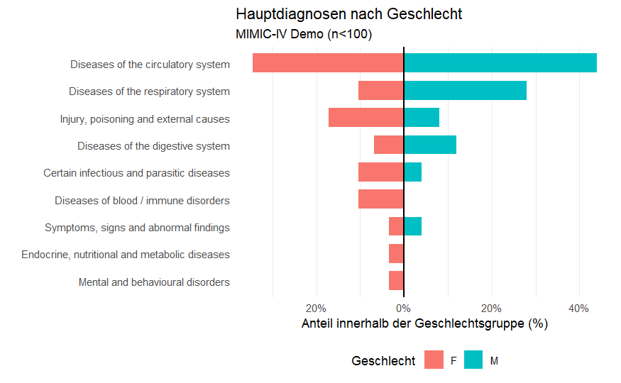

```r
diagnosis_order <- mimic_demo_cohort %>%
  filter(!is.na(icd10_group)) %>%
  count(icd10_group, sort = TRUE) %>%
  pull(icd10_group)

diagnosis_gender <- mimic_demo_cohort %>%
  filter(!is.na(icd10_group), !is.na(gender)) %>%
  count(gender, icd10_group) %>%
  group_by(gender) %>%
  mutate(
    percent = 100 * n / sum(n),
    percent_plot = ifelse(gender == "F", -percent, percent)
  ) %>%
  ungroup() %>%
  mutate(
    icd10_group = factor(
      icd10_group,
      levels = rev(diagnosis_order)
    )
  )
library(ggplot2)
ggplot(
  diagnosis_gender,
  aes(x = percent_plot, y = icd10_group, fill = gender)
) +
  geom_col(width = 0.7) +
  geom_vline(xintercept = 0, linewidth = 0.6) +
  scale_x_continuous(
    labels = function(x) paste0(abs(x), "%")
  ) +
  labs(
    title = "Hauptdiagnosen nach Geschlecht",
    subtitle = "MIMIC-IV Demo (n<100)",
    x = "Anteil innerhalb der Geschlechtsgruppe (%)",
    y = NULL,
    fill = "Geschlecht"
  ) +
  theme_minimal() +
  theme(
    panel.grid.major.y = element_blank(),
    legend.position = "bottom"
  )
```

Hinweis: Beachten Sie, dass durch die Beschränkung auf icd_version == 10 nur Hauptdiagnosen berücksichtigt werden, die nach ICD-10 kodiert wurden. ICU-Aufenthalte mit einer ICD-9-Hauptdiagnose erhalten daher in den entsprechenden Diagnosevariablen den Wert NA. Für diese Übung konzentrieren wir uns bewusst auf ICD-10. Für eine vollständige Analyse müssten ICD-9- und ICD-10-Diagnosen in gemeinsame klinische Diagnosegruppen überführt werden.

## Einfluss des Geschlechts auf Verteilung und Zusammenhänge

EDA und verschiedene Zusammenhänge in Full Cohort (aus Code, den ich schon habe)

Suchen Sie sich aus dem Full Cohort Datensatz 2 Variablen aus - deren Verteilung Sie mit Histogramm oder Dichteverteilung analysieren wollen - deren Verteilung Sie mit Boxplot analysieren können - die Sie im Scatterplot jeweils gegen eine andere Variable analysieren können

Erstellen Sie diese Abbildungen nochmal und bringen Sie Variable Gender mit ins Spiel.

## Mögliche Lösungen als Patchplot

Alterverteilung als Histogramm

```r
p1 <- ggplot(dat, aes(age)) +
  geom_histogram(bins = 30) +
  theme_minimal() +
  labs(title = "Age", x = "Age", y = "Count")
```

Altersverteilung als Histogramm mit Gender

```r
p2 <- ggplot(dat, aes(age, fill = gender_num)) +
  geom_histogram(bins = 30, position = "identity", alpha = .5) +
  theme_minimal() +
  labs(title = "Age by Gender", fill = "Gender")
```

Mean Arterial Pressure als Dichteverteilung

```r
p3 <- ggplot(dat, aes(map_1st)) +
  geom_density(fill = "grey", alpha = .5) +
  theme_minimal() +
  labs(title = "Mean Arterial Pressure", x = "MAP")
```

Mean Arterial Pressure als Dichteverteilung mit Gender

```r
p4 <- ggplot(dat, aes(map_1st, fill = gender_num)) +
  geom_density(alpha = .4) +
  theme_minimal() +
  labs(title = "MAP by Gender", fill = "Gender")
```

```r
p5 <- ggplot(dat, aes(stroke_flg, map_1st)) +
  geom_boxplot(outlier.shape = NA) +
  geom_jitter(width = .15, alpha = .2) +
  theme_minimal() +
  labs(title = "MAP and Stroke", x = "Stroke", y = "MAP")
```

```r
p6 <- ggplot(dat, aes(stroke_flg, map_1st, fill = gender_num)) +
  geom_boxplot() +
  theme_minimal() +
  labs(title = "MAP and Stroke by Gender",
       x = "Stroke", y = "MAP", fill = "Gender")
```

ICU LOS mit Raincloud Plot

```r
library(ggdist)

p7 <- ggplot(
  dat,
  aes(
    x = factor(1),
    y = icu_los_day
  )
) +
  stat_halfeye(
    adjust = 0.7,
    justification = -0.15,
    .width = 0,
    point_colour = NA,
    alpha = 0.7
  ) +
  stat_boxplot(
    geom = "errorbar",
    width = 0.08
  ) +
  geom_boxplot(
    width = 0.08,
    outlier.shape = NA,
    alpha = 0.8
  ) +
  geom_jitter(
    width = 0.12,
    alpha = 0.25,
    size = 0.7
  ) +
  coord_flip() +
  labs(
    title = "ICU Length of Stay",
    x = NULL,
    y = "ICU LOS (days)"
  ) +
  theme_minimal()
```

ICU LOS mit Raincloud Plot mit Gender

```r
p8 <- ggplot(
  dat,
  aes(
    x = gender_num,
    y = icu_los_day,
    fill = gender_num
  )
) +
  stat_halfeye(
    adjust = 0.7,
    justification = -0.15,
    .width = 0,
    point_colour = NA,
    alpha = 0.7,
    show.legend = FALSE
  ) +
  stat_boxplot(
    geom = "errorbar",
    width = 0.08
  ) +
  geom_boxplot(
    width = 0.08,
    outlier.shape = NA,
    alpha = 0.8,
    show.legend = FALSE
  ) +
  geom_jitter(
    width = 0.12,
    alpha = 0.25,
    size = 0.7,
    show.legend = FALSE
  ) +
  coord_flip() +
  labs(
    title = "ICU Length of Stay by Gender",
    x = "Gender",
    y = "ICU LOS (days)"
  ) +
  theme_minimal()
```

Alter vs. SOFA Scatterplot

```r
p9 <- ggplot(dat, aes(age, sofa_first)) +
  geom_point(alpha = .3) +
  geom_smooth(method = "lm") +
  theme_minimal() +
  labs(title = "Age and SOFA", x = "Age", y = "SOFA")
```

Alter vs. SOFA nach Gender Scatterplot mit Gender

```r
p10 <- ggplot(dat, aes(age, sofa_first, color = gender_num)) +
  geom_point(alpha = .3) +
  geom_smooth(method = "lm") +
  theme_minimal() +
  labs(title = "Age and SOFA by Gender", color = "Gender")
```

Patchwork Plot für 10 Plots (5x2)

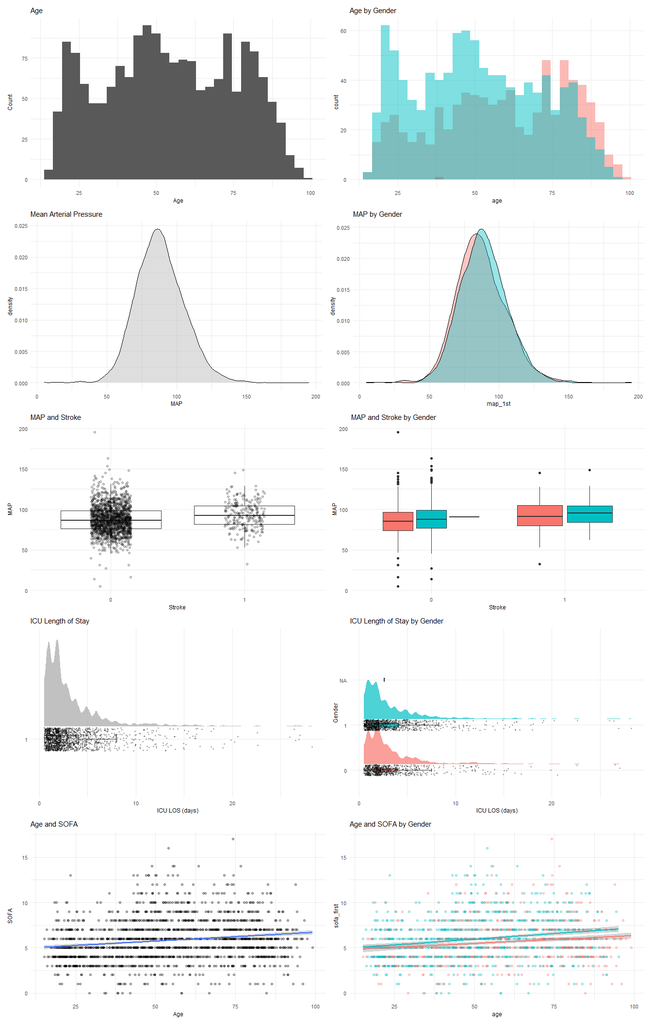

```r
library(patchwork)

patchplot <-
  (p1 | p2) /
  (p3 | p4) /
  (p5 | p6) /
  (p7 | p8) /
  (p9 | p10) &
  theme(
    legend.position = "none",
    plot.title = element_text(size = 11),
    axis.title = element_text(size = 9),
    axis.text = element_text(size = 8)
  )

patchplot
```

## Jeder gegen Jeden: Pairs Plot

Schließlich können Sie in einem Pairs Plot einige ausgewählte Variablen nach Gender stratifizieren

Variablen auswählen

```r
fullcohortvariables <- dat %>%
  select(
    age,
    bmi,
    map_1st,
    hr_1st,
    sofa_first,
    icu_los_day,
    gender_num
  )

head(fullcohortvariables)
```

|  | age | bmi | map_1st | hr_1st | sofa_first | icu_los_day | gender_num |
| --- | --- | --- | --- | --- | --- | --- | --- |
| 1 | 72.36841 | 29.91279 | 92.0000 | 86 | 9 | 7.63 | 1 |
| 2 | 64.92076 | 20.12131 | 86.6667 | 85 | 5 | 1.14 | 0 |
| 3 | 36.50000 | 27.11827 | 69.6667 | 135 | 5 | 2.86 | 0 |
| 4 | 44.49191 | NA | 101.0000 | 125 | 7 | 0.58 | 0 |
| 5 | 23.74217 | 28.46456 | 105.0000 | 107 | 7 | 1.75 | 1 |
| 6 | 36.54657 | 23.98240 | 104.0000 | 90 | 5 | 1.38 | 1 |

```r
if (!require("dplyr")) install.packages("dplyr")
library(dplyr)

dat %>% select(aline_flg,age,gender_num,weight_first,bmi,sapsi_first,sofa_first,day_28_flg,mort_day_censored,stroke_flg,pco2_first,tco2_first)
```

[output not shown]

[output cut: 990 more lines]

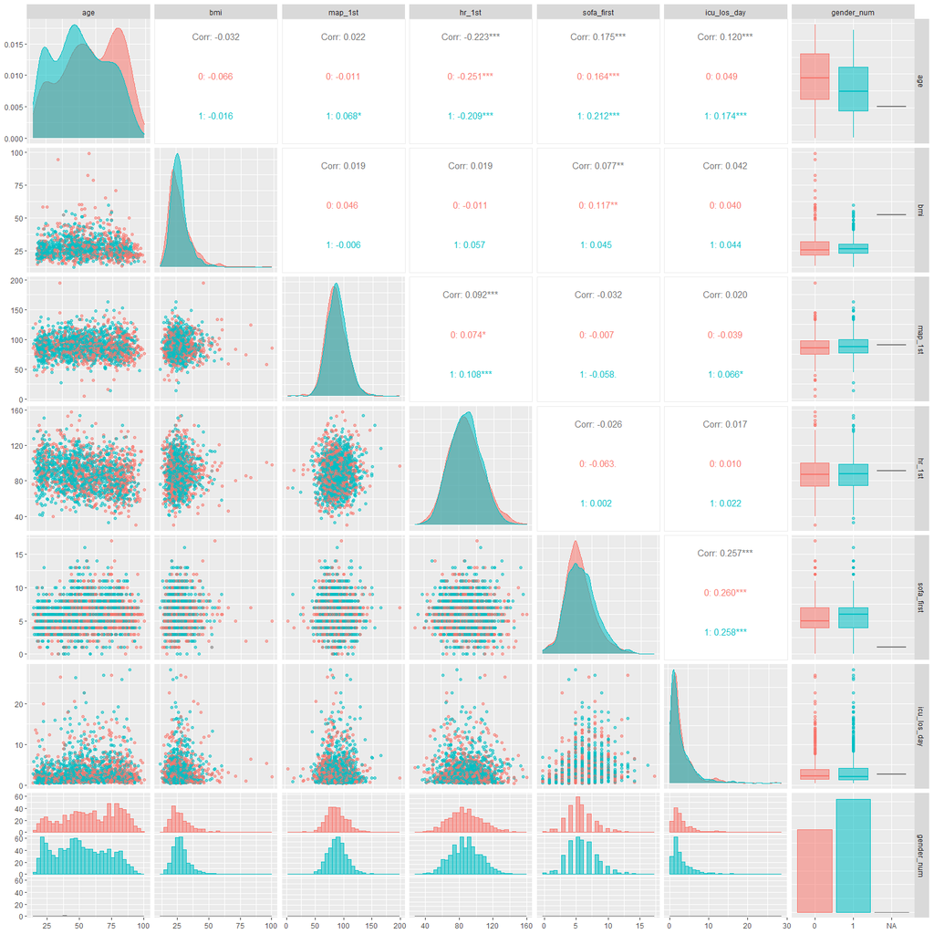

```r
if (!require("GGally")) install.packages("GGally")
library(GGally)


GGally::ggpairs(
  fullcohortvariables,
  #columns = 1:6,
  mapping = aes(
    color = gender_num,
    fill = gender_num,
    alpha = 0.5
  ),
  progress = FALSE
)
```

# Test, Model, Explain – Evidenz aus klinischen Daten gewinnen

Suchen Sie sich nun für die Durchführung eines statistischen Tests eine abhängige Variable aus, die Sie interessant finden, um den Einfluss des Geschlechts zu untersuchen

## Statistischer Test zu ICU LOS in Abhängigkeit vom Geschlecht

### Verteilung visualisieren

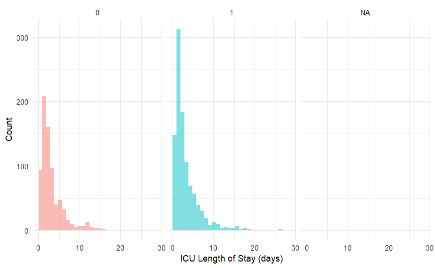

```r
ggplot(dat, aes(icu_los_day, fill = gender_num)) +
  geom_histogram(bins = 30, alpha = 0.5, position = "identity") +
  facet_wrap(~ gender_num) +
  theme_minimal() +
  labs(
    x = "ICU Length of Stay (days)",
    y = "Count"
  ) +
  theme(legend.position = "none")
```

### Verteilung testen

Shapiro-Wilk-Test

```r
dat %>%
  filter(!is.na(gender_num), !is.na(icu_los_day)) %>%
  group_by(gender_num) %>%
  summarise(
    n = n(),
    p_value = shapiro.test(icu_los_day)$p.value
  )
```

| gender_num | n | p_value |
| --- | --- | --- |
| 0 | 750 | 1.594537e-34 |
| 1 | 1025 | 1.089233e-39 |

### Homoskedastizität testen

Bartlett-Test

```r
bartlett.test(
  icu_los_day ~ gender_num,
  data = dat %>% filter(!is.na(gender_num), !is.na(icu_los_day))
)
```

```
    Bartlett test of homogeneity of variances

data:  icu_los_day by gender_num
Bartlett's K-squared = 1.1343, df = 1, p-value = 0.2869
```

Levene-Test

```r
library(car)

leveneTest(
  icu_los_day ~ gender_num,
  data = dat %>% filter(!is.na(gender_num), !is.na(icu_los_day))
)
```

```
Levene's Test for Homogeneity of Variance (center = median)
        Df F value Pr(>F)
group    1   0.349 0.5548
      1773
```

### Statistischer Test

Statistischer Test Da ICU LOS typischerweise nicht normalverteilt ist, bietet sich der Wilcoxon-Rangsummentest für die beiden unabhängigen Gruppen an:

```r
wilcox.test(
  icu_los_day ~ gender_num,
  data = dat %>% filter(!is.na(gender_num), !is.na(icu_los_day))
)
```

```
    Wilcoxon rank sum test with continuity correction

data:  icu_los_day by gender_num
W = 401183, p-value = 0.1151
alternative hypothesis: true location shift is not equal to 0
```

Falls die Voraussetzungen für einen parametrischen Test hinreichend erfüllt sind, alternativ der Welch-t-Test:

```r
t.test(
  icu_los_day ~ gender_num,
  data = dat %>% filter(!is.na(gender_num), !is.na(icu_los_day))
)
```

```
    Welch Two Sample t-test

data:  icu_los_day by gender_num
t = 0.31972, df = 1646, p-value = 0.7492
alternative hypothesis: true difference in means between group 0 and group 1 is not equal to 0
95 percent confidence interval:
 -0.2634125  0.3660135
sample estimates:
mean in group 0 mean in group 1
        3.37652         3.32522
```

Kein Post-hoc-Test erforderlich: gender_num umfasst zwei zu vergleichende Gruppen. Der statistische Test führt den relevanten Gruppenvergleich daher bereits direkt durch. Post-hoc-Tests werden insbesondere relevant, wenn eine Variable drei oder mehr Gruppen umfasst.

Führen Sie diese Schritte nun für einen Zusammenhang durch, der Sie interessiert und beschreiben/zeigen Sie anschließend die Daten.

## Zusammenhänge modellieren: Multivariable lineare Regression zur ICU Length of Stay

Mit einem multivariablen linearen Regressionsmodell kann untersucht werden, wie mehrere Variablen gleichzeitig mit der ICU Length of Stay zusammenhängen. In Anlehnung an Unit 7 verwenden wir Alter, Geschlecht, Erkrankungsschwere, Blutdruck und Kreatinin als exemplarische Prädiktoren.

```r
lm_dat <- dat %>%
  select(
    icu_los_day,
    gender_num,
    age,
    sofa_first,
    map_1st,
    creatinine_first
  ) %>%
  na.omit()

lm_model <- lm(
  icu_los_day ~ gender_num + age + sofa_first +
    map_1st + creatinine_first,
  data = lm_dat
)

summary(lm_model)
```

```
Call:
lm(formula = icu_los_day ~ gender_num + age + sofa_first + map_1st +
    creatinine_first, data = lm_dat)

Residuals:
    Min      1Q  Median      3Q     Max
-5.8335 -1.7263 -0.8229  0.6672 24.7322

Coefficients:
                  Estimate Std. Error t value Pr(>|t|)
(Intercept)       0.135222   0.466964   0.290 0.772174
gender_num1      -0.009241   0.156692  -0.059 0.952980
age               0.013648   0.003707   3.681 0.000239 ***
sofa_first        0.364278   0.033853  10.761  < 2e-16 ***
map_1st           0.006201   0.004281   1.449 0.147620
creatinine_first -0.202614   0.072199  -2.806 0.005066 **
---
Signif. codes:  0 ‘***’ 0.001 ‘**’ 0.01 ‘*’ 0.05 ‘.’ 0.1 ‘ ’ 1

Residual standard error: 3.153 on 1758 degrees of freedom
Multiple R-squared:  0.07773,   Adjusted R-squared:  0.0751
F-statistic: 29.63 on 5 and 1758 DF,  p-value: < 2.2e-16
```

Regressionskoeffizienten visualisieren

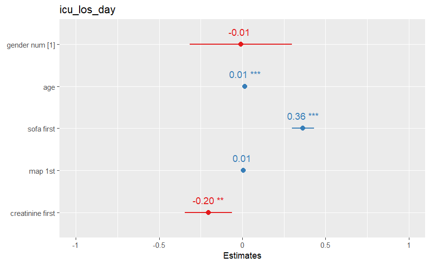

```r
library(sjPlot)

plot_model(
  lm_model,
  type = "est",
  show.values = TRUE,
  value.offset = .3
)
```

Jeder Koeffizient beschreibt den Zusammenhang mit icu_los_day, während die übrigen Variablen im Modell berücksichtigt werden. Bei gender_num beschreibt der Koeffizient den Unterschied zur Referenzgruppe. Das entspricht der in Unit 7 verwendeten Logik der multivariablen linearen Regression und des Koeffizientenplots.

## Vorhersagen erklären

Während sich bei der linearen Regression die Modellkoeffizienten direkt interpretieren lassen, bestehen Random Forests aus einer Vielzahl von Entscheidungsbäumen. Dadurch können auch komplexere und nichtlineare Zusammenhänge modelliert werden, das resultierende Modell ist jedoch nicht mehr unmittelbar interpretierbar. Methoden der Explainable Artificial Intelligence (XAI) können dabei helfen, das Verhalten solcher Modelle zu untersuchen.

Im folgenden Beispiel wird ein Random Forest zur Vorhersage der 28-Tage-Mortalität (day_28_flg) trainiert. Neben Alter, Erkrankungsschwere und Vitalparametern wird auch gender_num als Prädiktor berücksichtigt.

RF trainieren:

```r
library(randomForest)

rf_dat <- dat %>%
  select(
    day_28_flg,
    gender_num,
    age,
    sofa_first,
    sapsi_first,
    map_1st,
    hr_1st
  ) %>%
  na.omit()

set.seed(123)

rf_model <- randomForest(
  day_28_flg ~ gender_num + age + sofa_first +
    sapsi_first + map_1st + hr_1st,
  data = rf_dat,
  ntree = 500,
  importance = TRUE
)

rf_model
```

```
Call:
 randomForest(formula = day_28_flg ~ gender_num + age + sofa_first +      sapsi_first + map_1st + hr_1st, data = rf_dat, ntree = 500,      importance = TRUE)
               Type of random forest: classification
                     Number of trees: 500
No. of variables tried at each split: 2

        OOB estimate of  error rate: 15.2%
Confusion matrix:
     0  1 class.error
0 1386 52  0.03616134
1  204 42  0.82926829
```

Der Random Forest kombiniert die Vorhersagen vieler Entscheidungsbäume. Anders als bei einem einzelnen Entscheidungsbaum kann das gesamte Modell daher nicht sinnvoll als ein Baum dargestellt werden. ## Welche Variablen verwendet das Modell? Einen ersten Überblick liefert die Variable Importance. Sie beschreibt, welche Variablen für die Entscheidungen des Random Forest besonders relevant sind.

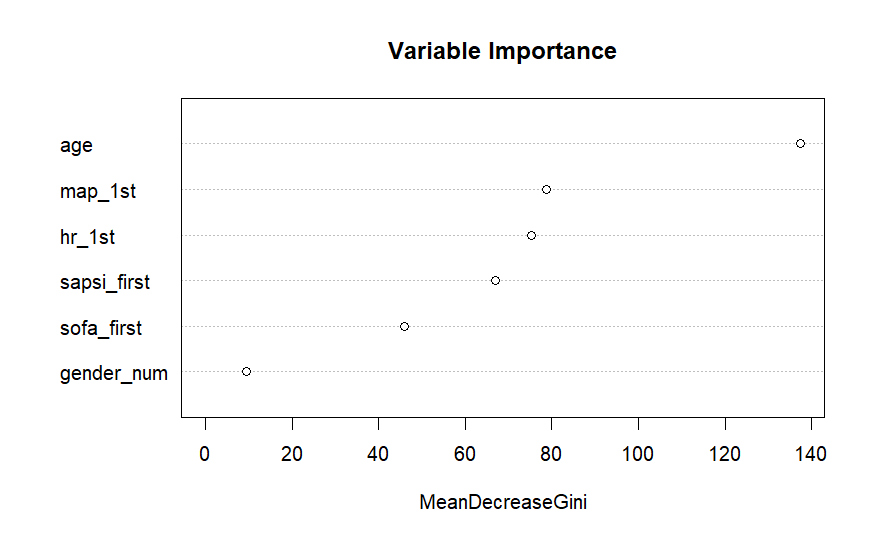

```r
varImpPlot(
  rf_model,
  type = 2,
  main = "Variable Importance"
)
```

Eine hohe Variable Importance bedeutet, dass das Modell eine Variable häufig bzw. gewinnbringend für seine Vorhersagen verwendet. Daraus kann jedoch nicht geschlossen werden, dass die Variable einen kausalen Einfluss auf die Mortalität besitzt.

## Individual Conditional Expectation (ICE)

Die Variable Importance zeigt, welche Variablen für das Modell relevant sind, aber noch nicht, wie sich unterschiedliche Werte einer Variable auf die Vorhersage auswirken. Dies kann mit einem ICE-Plot untersucht werden. Exemplarisch betrachten wir den SOFA-Score:

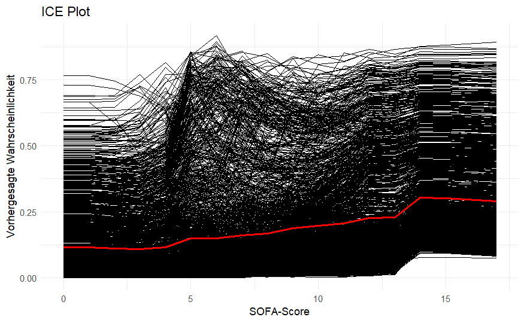

```r
library(pdp)

ice <- partial(
  rf_model,
  pred.var = "sofa_first",
  train = rf_dat,
  ice = TRUE,
  prob = TRUE,
  which.class = 2,
  plot = TRUE,
  plot.engine = "ggplot2"
) +
  labs(
    title = "ICE Plot",
    x = "SOFA-Score",
    y = "Vorhergesagte Wahrscheinlichkeit"
  ) +
  theme_minimal()

ice
```

Jede ICE-Kurve zeigt für eine einzelne Beobachtung, wie sich die vom Modell vorhergesagte Wahrscheinlichkeit verändert, wenn sofa_first variiert wird, während die übrigen Merkmale dieser Beobachtung konstant gehalten werden. Unterschiedliche Verläufe können auf heterogene oder nichtlineare Zusammenhänge hinweisen.

## SHAP-Werte berechnen

SHAP-Werte betrachten die Vorhersagen noch stärker auf Ebene einzelner Beobachtungen. Sie beschreiben, wie einzelne Merkmale dazu beitragen, eine Modellvorhersage gegenüber einer durchschnittlichen Vorhersage zu verändern. Zunächst werden die Prädiktoren ausgewählt:

```r
X <- rf_dat %>%
  select(
    gender_num,
    age,
    sofa_first,
    sapsi_first,
    map_1st,
    hr_1st
  )
```

Für die Berechnung wird eine Funktion definiert, die die vorhergesagte Wahrscheinlichkeit der 28-Tage-Mortalität zurückgibt:

```r
pred_fun <- function(object, newdata) {
  predict(object, newdata, type = "prob")[, 2]
}
```

Anschließend werden die SHAP-Werte berechnet:

```r
library(fastshap)
library(shapviz)

set.seed(123)

shap_values <- fastshap::explain(
  rf_model,
  X = X,
  pred_wrapper = pred_fun,
  nsim = 100,
  adjust = TRUE
)

sv <- shapviz(
  shap_values,
  X = X,
  baseline = mean(pred_fun(rf_model, X))
)
```

## SHAP Beeswarm Plot

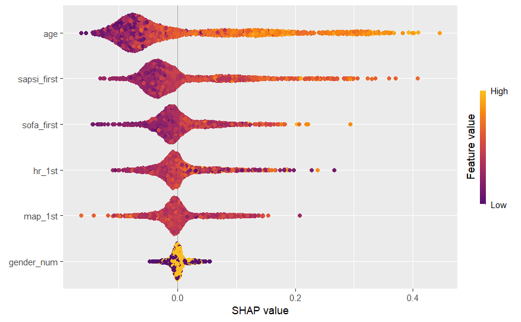

```r
sv_importance(
  sv,
  kind = "beeswarm"
)
```

Der SHAP-Beeswarm verbindet globale und individuelle Modellinterpretation. Variablen mit größerem Einfluss auf die Modellvorhersagen erscheinen weiter oben. Jeder Punkt repräsentiert eine Beobachtung. Die Position auf der x-Achse zeigt, ob das jeweilige Merkmal die vorhergesagte Wahrscheinlichkeit gegenüber dem Ausgangswert erhöht oder reduziert.

Wird Gender vom Modell für die Mortalitätsvorhersage genutzt? Wie groß ist sein Beitrag im Vergleich zu Alter, SOFA, SAPS und Vitalparametern? Wichtig: Variable Importance, ICE und SHAP erklären das Verhalten des trainierten Modells. Sie zeigen nicht, dass eine Variable die 28-Tage-Mortalität kausal verursacht. Damit aus einer Modellvorhersage klinische Evidenz oder sogar eine Handlungsempfehlung werden kann, sind weitere Schritte wie Validierung, Bias-Analyse und die Einordnung in klinische Evidenz notwendig.